# Forecasting Men's Deadlifts in Powerlifting Competitions

### Exog Candidate: Drug Testing

**Exog Candidates:** What do I want to flag as a viable exog this time that is not so closely colinear? Candidates may be:

- Tested vs not tested
- Meet Country
- Native Country of the Competitor
- Equipment
- The IPF Points which is a formula that adjusts for age and bodyweight

The two candidates that are most interesting to me is tested/not-tested and equipment. The relationship of testing to women's powerlifting surprised me with the highest weights occuring in drug-tested competitions. That said, there are also drugs that can be taken that, if stopped before competition, are not detectable. Drug testing and its initiation in the field is a story unto its own and I feel is a definite presence in the sport. I'm choosing testing as well because it is a disruptor, a shock if you will and unlike the others, is not directly related to brute strength.

```python
print(df['Tested'].value_counts())
print(df['Tested'].isna().sum())
```

```
Tested
Yes    200
Name: count, dtype: int64
272
```

```python
#Prepare the Exog - Turn it into a Binary. Coerce Nans to Not-Tested

#Turn Tested Nas into Binary with 1=tested and 0=untested
df['Tested_binary'] = (df['Tested']== 'Yes').astype(int)
df['Tested_binary'].value_counts()
df = df.drop(columns='Tested')
df['Tested_binary'].value_counts()
```

```
Tested_binary
0    272
1    200
Name: count, dtype: int64
```

```python
print("freq:", df.index.freq)
```

```
freq: <MonthBegin>
```

### Check NAs

```python
#Find out how much of the data is missing
NA_summary = (100 * pd.isnull(df).sum() / len(df)).sort_values(ascending=False)
NA_summary
```

```
Year             0.211864
Deadlift         0.211864
Tested_binary    0.000000
dtype: float64
```

```python
#Remove NAs
df =df.dropna()
```

```python
#Missing months examination
missing_months = df.asfreq("MS").isna().sum()
missing_months
```

```
Year             1
Deadlift         1
Tested_binary    1
dtype: int64
```

```python
#Impute missing months using time
df["Year"] = df["Year"].interpolate(method="time")
df["Deadlift"] = df["Deadlift"].interpolate(method="time")
df["Tested_binary"] = df["Tested_binary"].interpolate(method="time")
df.isna().sum()
```

```
Year             0
Deadlift         0
Tested_binary    0
dtype: int64
```

```python
df.isna().sum()
```

```
Year             0
Deadlift         0
Tested_binary    0
dtype: int64
```

### Check Outliers

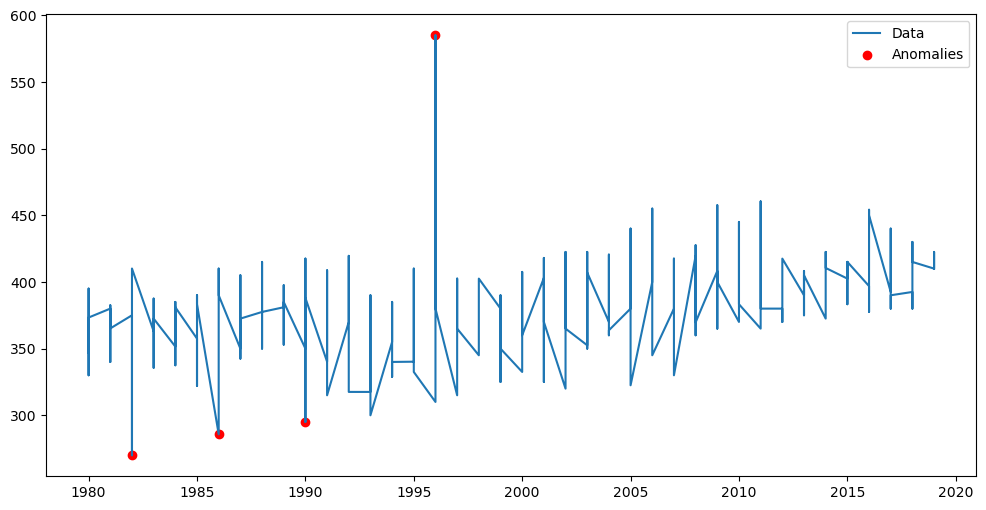

```python
#I'm trying a different outlier detection method this assignment
#However in order to use DBSCAN I have to impute the  missing months discovered above

df_outliers = df.copy()

clustering = DBSCAN(eps=10, min_samples=5).fit(df_outliers[['Deadlift']])
df_outliers['dbscan_anomaly'] = clustering.labels_

# Plot results
plt.figure(figsize=(12, 6))
plt.plot(df_outliers['Year'], df_outliers['Deadlift'], label='Data')
plt.scatter(df_outliers['Year'][df_outliers['dbscan_anomaly'] == -1], df_outliers['Deadlift'][df_outliers['dbscan_anomaly'] == -1], color='red', label='Anomalies')
plt.legend()
plt.show()
```

```python
#Outlier Handling

outliers = df_outliers['Deadlift'][df_outliers['dbscan_anomaly'] == -1]
outliers
```

```
Month
1982-06-01    270.00
1986-01-01    285.76
1990-08-01    295.00
1996-06-01    585.00
Name: Deadlift, dtype: float64
```

```python
#I'm actually going to impute one outlier
df = df.drop(pd.Timestamp("1996-06-01"))

df = df.asfreq("MS")  # reintroduce the missing month as NaN
df["Year"] = df["Year"].interpolate(method="time")
df["Deadlift"] = df["Deadlift"].interpolate(method="time")
df["Tested_binary"] = df["Tested_binary"].interpolate(method="time")
df.isna().sum()
```

```
Year             0
Deadlift         0
Tested_binary    0
dtype: int64
```

```python
print("freq:", df.index.freq)
```

```
freq: <MonthBegin>
```

```python
df['Tested_binary'].value_counts()
```

```
Tested_binary
0.0    273
1.0    199
Name: count, dtype: int64
```

### Data Preparation, Establishing Stationarity/Nonstationarity But Do Not Resolve

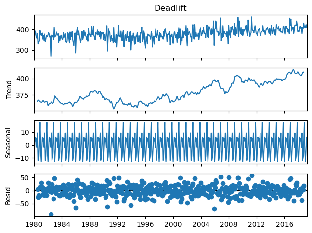

```python
#Decomposition using the imputed series used in the outlier scan

decomposed = seasonal_decompose(df["Deadlift"], period=12, model='additive')
decomposed.plot()
plt.show()
```

**Observation:** This looks very seasonal like the women's. There is much less variance as noted before. The residuals are extremely close fitting. There is a clear upward trend. I'm beginning to wonder if this data is too well-behaved to be modeled by the Kalman Filter.

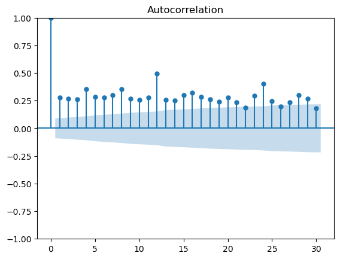

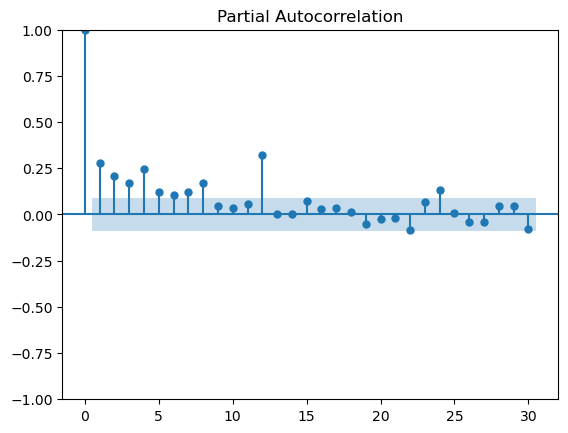

```
ADF Statistic: -1.229904116945492
p-value: 0.6606012765372553
Critical Values: {'1%': np.float64(-3.44464601455782), '5%': np.float64(-2.867843681679954), '10%': np.float64(-2.570127622873346)}
The data is not stationary (p-value >= 0.05).
```

```python
#ACF and PACF. ADF Test

# ACF and PACF plots
plot_acf(df['Deadlift'], lags=30)
plt.show()

plot_pacf(df['Deadlift'], lags=30)
plt.show()

adf_test = adfuller(df['Deadlift'])
print("ADF Statistic:", adf_test[0])
print("p-value:", adf_test[1])
print("Critical Values:", adf_test[4])
if adf_test[1] < 0.05:
    print("The data is stationary (p-value < 0.05).")
else:
    print("The data is not stationary (p-value >= 0.05).")
```

### Test/Train Split for Time Series

```python
print("freq:", df.index.freq)
```

```
freq: <MonthBegin>
```

```python
#Test/Train with Validation to Avoid Leakage While Tuning Hyperparameters
n = len(df)

train_end = int(0.8 * n)
val_end   = int(0.9 * n)

train_data = df['Deadlift'].iloc[:train_end]
val_data   = df['Deadlift'].iloc[train_end:val_end]
test_data  = df['Deadlift'].iloc[val_end:]

exog_train = df['Tested_binary'].iloc[:train_end]
exog_val   = df['Tested_binary'].iloc[train_end:val_end]
exog_test  = df['Tested_binary'].iloc[val_end:]

train_data = train_data.astype(float)
print("NaNs:", np.isnan(train_data).sum())
print("Infs:", np.isinf(train_data).sum())
print(train_data.shape)
print(val_data.shape)
print(test_data.shape)
print("freq:", train_data.index.freq)
```

```
NaNs: 0
Infs: 0
(377,)
(47,)
(48,)
freq: <MonthBegin>
```

### Model Fitting

I'm going to go with a Local Linear Trend with Seasonal because I tried Kalman Filter first and was encountering issues with is converging. Based on this, Chat, recommended Local Linear Trend because:

- it handles a clear trend
- seasonality
- noise can be minimal
- it handles missing values
- it does well with structure with some noise

```python
#Local Linear Trend # I found this online and it seems like it suited my needs

model = UnobservedComponents(
    train_data,
    level="local linear trend",   # upward trend
    seasonal=12                   # annual seasonality with monthly data
).fit(disp=False)
```

### Generate the Forecast

```python
#Set the steps
n_forecast = len(val_data)

#Generate predictions
forecast_1 = model.get_forecast(steps=n_forecast).predicted_mean
```

### Visualize the Forecast

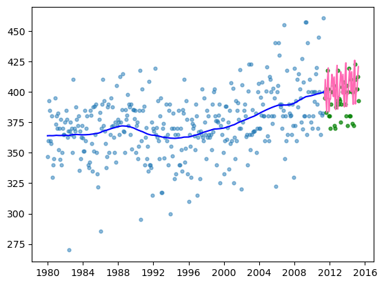

```python
#Training Data
plt.scatter(train_data.index, train_data, label="Observed", s=12, alpha=0.5)

# Latent Pattern / True State
plt.plot(train_data.index, model.level.smoothed, label="True State", color="blue")

# Forecast
plt.plot(val_data.index, forecast_1, label="Forecast", color="hotpink")

#Test Data
plt.scatter(val_data.index, val_data, label="Test Data", s=12, alpha=0.7, color='green')
```

**Observation:** After checking my indexing and length of arrays over and over again, I've settled on the forecast looking comblike because it's capturing seasonality. The next step may be to remove seasonality from the model to see the underlying forecasted trend. I don't like this model. It doesn't really do anything for us in terms of clarifying the relationships. I do however like the hidden state line. I think that is helpful.

### Extract Metrics

```python
#Calculate Metrics
mape = mean_absolute_percentage_error(val_data, forecast_1) * 100
print(f"Mean Absolute Percentage Error (MAPE): {mape:.2f}%")

print("Observed mean:", train_data.mean())
print("Level mean:", model.level.smoothed.mean())
print("Level std:", np.std(model.level.smoothed_cov))
print("Seasonal mean:", model.seasonal.smoothed.mean())
print("Fitted mean:", model.fittedvalues.mean())
```

```
Mean Absolute Percentage Error (MAPE): 4.38%
Observed mean: 373.28589794320993
Level mean: 373.27537885278457
Level std: 2.2185218854564472
Seasonal mean: 0.010105968020097406
Fitted mean: 372.65323885484264
```

### Actual Kalman Filter with Baseline Transition Matrix

```python
# Define state-space model with baseline transition matrix
#I'm starting with a baseline

transition_matrix = [
    [1, 0, 0],  # Trend component
    [0, 1, 0],  # Trend velocity
    [0, 0, 1],  # Seasonal component
]
observation_matrix = [[1, 0, 1]]  # Observations indicate trend and seasonality.
H = observation_matrix

# Reinitialize Kalman Filter with seasonality
kf = KalmanFilter(
    transition_matrices=transition_matrix,
    observation_matrices=observation_matrix,
    initial_state_mean=[0, 0, 0],
    initial_state_covariance=np.eye(3),
    transition_covariance=np.diag([0.1, 0.1, 0.1]),  # Process noise
    observation_covariance=[[5]]  # Measurement noise
)


# Fit the Kalman Filter
kf = kf.em(train_data, n_iter=10)

# Apply the filter and smoother
filtered_state_mean, filtered_state_covariance = kf.filter(train_data)
smoothed_state_mean, smoothed_state_covariance = kf.smooth(train_data)#Hidden state

#Forecast
n_forecast = len(val_data)
forecast_mean, forecast_covariance = filtered_state_mean[-1], filtered_state_covariance[-1]
forecast = []

for _ in range(n_forecast):
    forecast_mean, forecast_covariance = kf.filter_update(
        forecast_mean, forecast_covariance, observation=None
    )
    forecast.append(forecast_mean[0] + forecast_mean[2])  # Combine trend and seasonality

forecast_index = range(len(val_data))
```

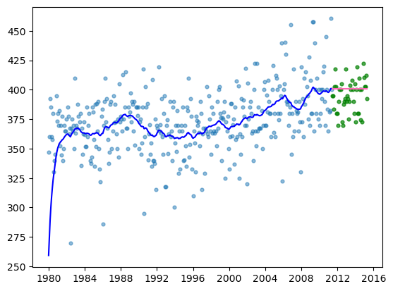

```python
#Plotting Hidden State and Forecast

hidden2 = (H @ smoothed_state_mean.T).ravel()

plt.scatter(train_data.index, train_data, label="Observed", s=12, alpha=0.5)

# Latent Pattern / True State
plt.plot(train_data.index, hidden2, label="True State", color="blue")

# Forecast
plt.plot(val_data.index, forecast, label="Forecast", color="hotpink")

#Test Data
plt.scatter(val_data.index, val_data, label="Test Data", s=12, alpha=0.7, color='green')
```

```python
mape = mean_absolute_percentage_error(val_data, forecast) * 100
print(f"Mean Absolute Percentage Error (MAPE): {mape:.2f}%")

print("Observed mean:", train_data.mean())
print("Level mean:", hidden2.mean())
print("Level std:", np.std(hidden2))
```

```
Mean Absolute Percentage Error (MAPE): 3.13%
Observed mean: 373.28589794320993
Level mean: 371.395936829988
Level std: 16.759908129408924
```

**Observation:** This is quite good. The forecast seems sensible and the hidden state reflects the shape of the data and its upward trend.

### Remove Seasonality from Observation Matrix in the Kalman Filter

```python
# Define state-space model with trend
transition_matrix = [
    [1, 1],  # level_t+1 = level_t + slope_t
    [0, 1],  # slope_t+1 = slope_t
]
observation_matrix = [[1, 0]]  # Observations depend on trend. This is H

# Reinitialize Kalman Filter without
kf = KalmanFilter(
    transition_matrices=transition_matrix,
    observation_matrices=observation_matrix,
    initial_state_mean=[0, 0],
    initial_state_covariance=np.eye(2),
    transition_covariance=np.diag([0.1, 0.1]),  # Process noise
    observation_covariance=[[5]]  # Measurement noise
)

H = observation_matrix

# Fit the Kalman Filter
kf = kf.em(train_data, n_iter=10)

# Apply the filter and smoother
filtered_state_mean, filtered_state_covariance = kf.filter(train_data)
smoothed_state_mean2, smoothed_state_covariance = kf.smooth(train_data)


# Forecast
n_forecast = len(val_data)
F = transition_matrix
H = observation_matrix

state_mean = filtered_state_mean[-1].copy()
state_forecasts = []

for _ in range(n_forecast):
    state_mean = F @ state_mean
    state_forecasts.append(state_mean.copy())

state_forecasts = np.array(state_forecasts)          # (h, 2)
forecast3 = (H @ state_forecasts.T).ravel()
```

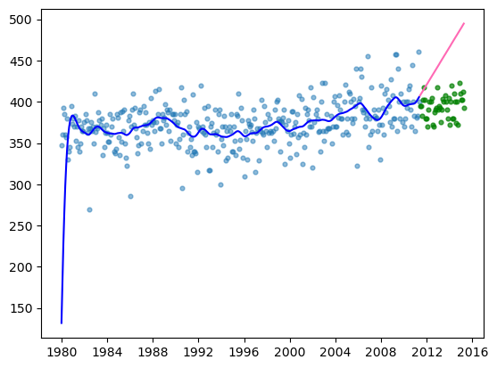

```python
#Training Data

hidden3 = (H @ smoothed_state_mean2.T).ravel()

plt.scatter(train_data.index, train_data, label="Observed", s=12, alpha=0.5)

# Latent Pattern / True State
plt.plot(train_data.index, hidden3, label="True State", color="blue")

# Forecast
plt.plot(val_data.index, forecast3, label="Forecast", color="hotpink")

#Test Data
plt.scatter(val_data.index, val_data, label="Test Data", s=12, alpha=0.7, color='green')
```

```python
mape = mean_absolute_percentage_error(val_data, forecast3) * 100
print(f"Mean Absolute Percentage Error (MAPE): {mape:.2f}%")
print("Observed mean:", train_data.mean())
print("Level mean:", hidden3.mean())
print("Level std:", np.std(hidden3))
```

```
Mean Absolute Percentage Error (MAPE): 14.56%
Observed mean: 373.28589794320993
Level mean: 371.5851230635573
Level std: 22.73499123469006
```

**Observation:** This shows that seasonality is really keeping the forecast undercontrol in the last iteration. Removing seasonality from the observation matrix has a definite negative affect on the MAPE and the appearance of the forecast.

### Add Exog Variable (Tested Binary) to the Best Kalman Filter Iteration

**Domain Context on Testing:** Drug testing entered powerlifting competitions in the 1980s and 90s with greater penetration than it is bodybuilding, where performance enhancing drugs are still politely tolerated to this day. What I didn't know until I spoke to a female powerlifter at the gym was that testing happens AFTER the athlete has completed all lifts and is based on from what she can tell, who lifts the heaviest, who "looks like they are juicing" and a random selection that is done in the record keeping system.

So athletes may anticipate getting tested before they lift if they "look" a certain way vis a vis their competitors.

```python
#I first have to calculate the coefficient of the Tested Binary
#Let's return to the easy version of Kalman Filter and get the coefficient for testing

results = UnobservedComponents(
    train_data,
    level="local linear trend",
    exog=exog_train
).fit(disp=False)

print(results.params)
train_data.shape
```

```
sigma2.irregular      504.763339
sigma2.level            0.123280
sigma2.trend            0.000065
beta.Tested_binary    -17.582298
dtype: float64
```

```
(377,)
```

```python
# Define Kalman Filter with Exog and Seasonal Component in the Transition Matrix


beta = np.array([-17.582298])  # (1,)

#I need to turn the exog train and test into a 2 dimensional matrix with (,1) as the number of exogs
exog_train_2d = exog_train.to_numpy().reshape(-1, 1)
exog_val_2d = exog_val.to_numpy().reshape(-1, 1)


#This is how the exog enters the model by taking the coefficient and multiplying it by the exog train and test matrices
obs_offset_train = (exog_train_2d @ beta).reshape(-1, 1)
obs_offset_test  = (exog_val_2d @ beta).reshape(-1, 1)

transition_matrix = [
    [1, 0, 0],  # Trend component
    [0, 1, 0],  # Trend velocity
    [0, 0, 1],  # Seasonal component
]
observation_matrix = [[1, 0, 1]]  # Observations depend on trend and seasonality. This is H

# Reinitialize Kalman Filter
kf = KalmanFilter(
    transition_matrices=transition_matrix,
    observation_matrices=observation_matrix,
    initial_state_mean=[0, 0, 0],
    observation_offsets=obs_offset_train,    #Exog
    initial_state_covariance=np.eye(3),
    transition_covariance=np.diag([0.1, 0.1, 0.1]),  # Process noise
    observation_covariance=[[5]]  # Measurement noise
)
H = observation_matrix


# Fit the Kalman Filter
kf = kf.em(train_data, n_iter=10)

# Apply the filter and smoother
filtered_state_mean, filtered_state_covariance = kf.filter(train_data)
smoothed_state_mean, smoothed_state_covariance = kf.smooth(train_data)

n_forecast = len(val_data)
state_mean = filtered_state_mean[-1].copy()

state_forecasts = []
for _ in range(n_forecast):
    state_mean = transition_matrix @ state_mean
    state_forecasts.append(state_mean.copy())

state_forecasts = np.array(state_forecasts)  # (h, 3)

y_forecast = (H @ state_forecasts.T).ravel() + obs_offset_test.ravel()
hidden4 = (H @ smoothed_state_mean.T).ravel()
```

```python
mape = mean_absolute_percentage_error(val_data, y_forecast) * 100
print(f"Mean Absolute Percentage Error (MAPE): {mape:.2f}%")
print("Observed mean:", train_data.mean())
print("Level mean:", hidden4.mean())
print("Level std:", np.std(hidden4))
```

```
Mean Absolute Percentage Error (MAPE): 3.66%
Observed mean: 373.28589794320993
Level mean: 380.42065047301276
Level std: 16.914794648361706
```

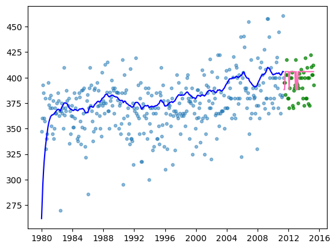

```python
#Plotting

plt.scatter(train_data.index, train_data, label="Observed", s=12, alpha=0.5)

# Latent Pattern / True State
plt.plot(train_data.index, hidden4, label="True State", color="blue")

# Forecast
plt.plot(val_data.index, y_forecast, label="Forecast", color="hotpink")

#Test Data
plt.scatter(val_data.index, val_data, label="Test Data", s=12, alpha=0.7, color='green')
```

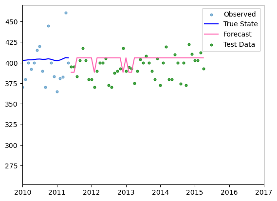

```python
#Let's take a closeup

plt.scatter(train_data.index, train_data, label="Observed", s=12, alpha=0.5)

# Latent Pattern / True State
plt.plot(train_data.index, hidden4, label="True State", color="blue")

# Forecast
plt.plot(val_data.index, y_forecast, label="Forecast", color="hotpink")

#Test Data
plt.scatter(val_data.index, val_data, label="Test Data", s=12, alpha=0.7, color='green')


plt.xlim(pd.Timestamp("2010-01-01"), None)
plt.legend()
plt.show()
```

**Observation:** The reason why the difference between tested and untested lifts is so constant is by virtue of the model itself adding the exog as additive and dictated by the -17 kg coefficient.

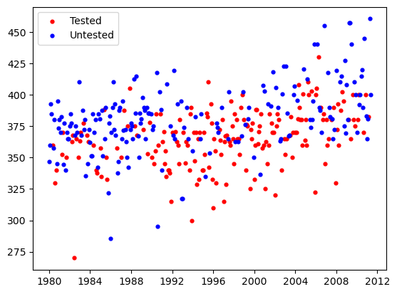

```python
#Let's separate out the tested from untested athletes here in the training data

mask_train_1 = exog_train_2d[:, 0] == 1 #Shows the tested
mask_train_0 = exog_train_2d[:, 0] == 0 #Shows the untested

# Plot
plt.scatter(
    train_data.index[mask_train_1],
    train_data[mask_train_1],
    color="red",
    s=12,
    label="Tested"
)

plt.scatter(
    train_data.index[mask_train_0],
    train_data[mask_train_0],
    color="blue",
    s=12,
    label="Untested"
)

plt.legend()
plt.show()
```

```python
#Final Model Run


beta = np.array([-17.582298])  # (1,)

#I need to turn the exog train and test into a 2 dimensional matrix with (,1) as the number of exogs
exog_train_2d = exog_train.to_numpy().reshape(-1, 1)
exog_test_2d = exog_test.to_numpy().reshape(-1, 1)


#This is how the exog enters the model by taking the coefficient and multiplying it by the exog train and test matrices
obs_offset_train = (exog_train_2d @ beta).reshape(-1, 1)
obs_offset_test  = (exog_test_2d  @ beta).reshape(-1, 1)

transition_matrix = [
    [1, 0, 0],  # Trend component
    [0, 1, 0],  # Trend velocity
    [0, 0, 1],  # Seasonal component
]
observation_matrix = [[1, 0, 1]]  # Observations depend on trend and seasonality. This is H

# Reinitialize Kalman Filter
kf = KalmanFilter(
    transition_matrices=transition_matrix,
    observation_matrices=observation_matrix,
    initial_state_mean=[0, 0, 0],
    observation_offsets=obs_offset_train,    #Exog
    initial_state_covariance=np.eye(3),
    transition_covariance=np.diag([0.1, 0.1, 0.1]),  # Process noise
    observation_covariance=[[5]]  # Measurement noise
)
H = observation_matrix


# Fit the Kalman Filter
kf = kf.em(train_data, n_iter=10)

# Apply the filter and smoother
filtered_state_mean, filtered_state_covariance = kf.filter(train_data)
smoothed_state_mean, smoothed_state_covariance = kf.smooth(train_data)

n_forecast = len(test_data)
state_mean = filtered_state_mean[-1].copy()

state_forecasts = []
for _ in range(n_forecast):
    state_mean = transition_matrix @ state_mean
    state_forecasts.append(state_mean.copy())

state_forecasts = np.array(state_forecasts)  # (h, 3)

y_forecast = (H @ state_forecasts.T).ravel() + obs_offset_test.ravel()
hidden4 = (H @ smoothed_state_mean.T).ravel()
```

[output not shown]

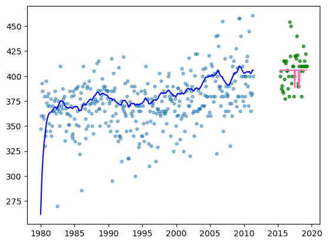

```python
#Final Model Testing with Test Data

mape = mean_absolute_percentage_error(test_data, y_forecast) * 100
print(f"Mean Absolute Percentage Error (MAPE): {mape:.2f}%")
print("Observed mean:", train_data.mean())
print("Level mean:", hidden4.mean())
print("Level std:", np.std(hidden4))


plt.scatter(train_data.index, train_data, label="Observed", s=12, alpha=0.5)

# Latent Pattern / True State
plt.plot(train_data.index, hidden4, label="True State", color="blue")

# Forecast
plt.plot(test_data.index, y_forecast, label="Forecast", color="hotpink")

#Test Data
plt.scatter(test_data.index, test_data, label="Test Data", s=12, alpha=0.7, color='green')
```

**Observation** This captures an interesting upwardly shifted hidden state with a space where the validation data was. I'm not sure what the standard is in industry - do we fill this in when using test data? The foreacast captures the conservativeness of the second model while also adding flucuations associated with the binary exog.

```python
models = pd.DataFrame({
    'Model Iterations' : ['Local Linear Trend', 'Kalman Baseline Transition with S and Trend Obs', 'Kalman No S but Trend and Level', 'Kalman Baseline with S and Exog', 'Kalman Baseline with S, Exog and Test Data'],
    'MAPE' : [4.38, 3.13, 14.56, 3.66, 3.29],
    'Observed Mean Kg': [373, 373, 373, 373, 373],
    'Level Mean Kg' : [373, 371, 371, 380, 380],
    'Level Std Kg': [2.2, 16.8, 22.73, 16.9, 16.9]
})

models
```

|  | Model Iterations | MAPE | Observed Mean Kg | Level Mean Kg | Level Std Kg |
| --- | --- | --- | --- | --- | --- |
| 0 | Local Linear Trend | 4.38 | 373 | 373 | 2.20 |
| 1 | Kalman Baseline Transition with S and Trend Obs | 3.13 | 373 | 371 | 16.80 |
| 2 | Kalman No S but Trend and Level | 14.56 | 373 | 371 | 22.73 |
| 3 | Kalman Baseline with S and Exog | 3.66 | 373 | 380 | 16.90 |
| 4 | Kalman Baseline with S, Exog and Test Data | 3.29 | 373 | 380 | 16.90 |

### Discussion

**Metrics** According to metrics, the best performing model for forecasting men's winning deadlifts is a Kalman Filter with an identity matrix as transition and seasonality and trend in the observation matrix. I wonder why the standard deviation increases so dramatically with using Kalman and not its "pre-packaged" version, Local Linear Trend. I would guess there is an internal mechanism that reduces variance. Or variance moved from slope to level.

**Best Model** I prefer model #4, a Kalman Filter with a baseline matrix for transition and seasonality and trend in the observation matrix as well as the exog of tested/not tested. You can see from Model 2 to 3, that seasonality is very important to capturing the data.

**What I Would Do Next Time** I think from what I can tell that this data might be better suited to the dynamics of a Hidden Markov model. I also think testing might have a nonlinear relationship to the winning lifts overtime. So perhaps a multiplicative model might tell us more. I had the urge to model tested and untested as two completely different hidden states that are also connected and for that I think I need to go to a different model.